# N5 Prelim Revision Booklet - Web Version

$(y+5)(y-4)$

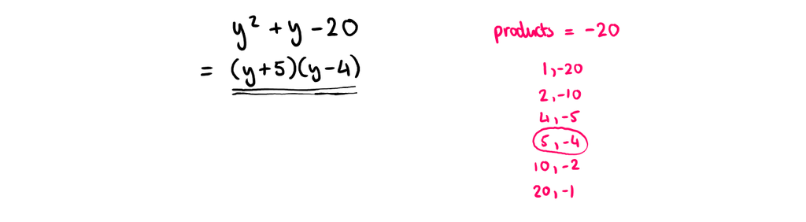

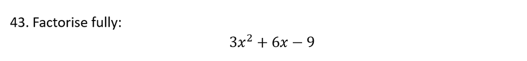

Always look to take a *common factor* first. However, there may still be *more to do* afterwards...

$3(x+3)(x-1)$

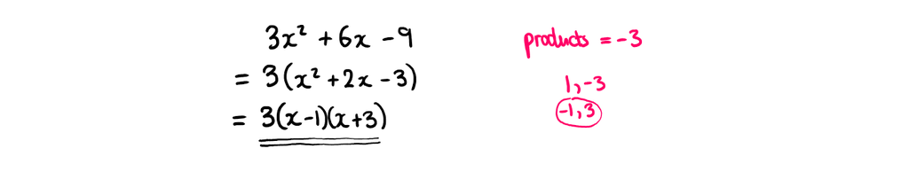

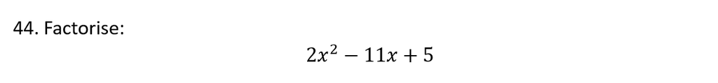

One approach is to find a pair of numbers that multiply to give 5, but that add to give -11 *when one of them is multiplied by 2 first.*

$(2x-1)(x-5)$

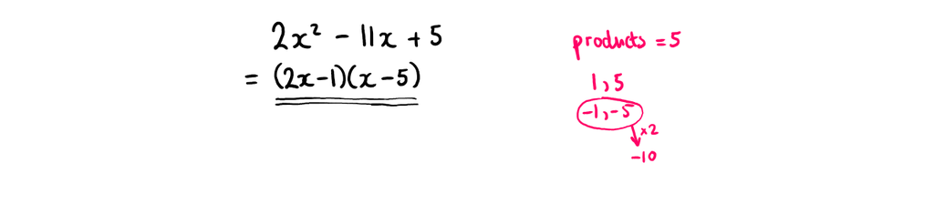

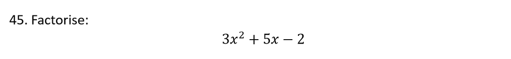

Once you think you have the correct answer, you can always multiply your brackets out again to *check you get back to the original expression*.

$(3x-1)(x+2)$

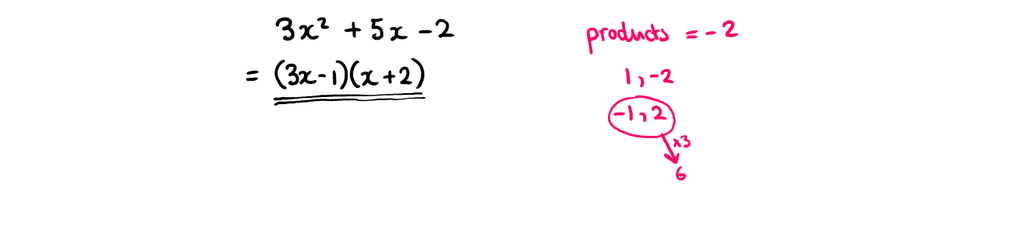

## Statistics

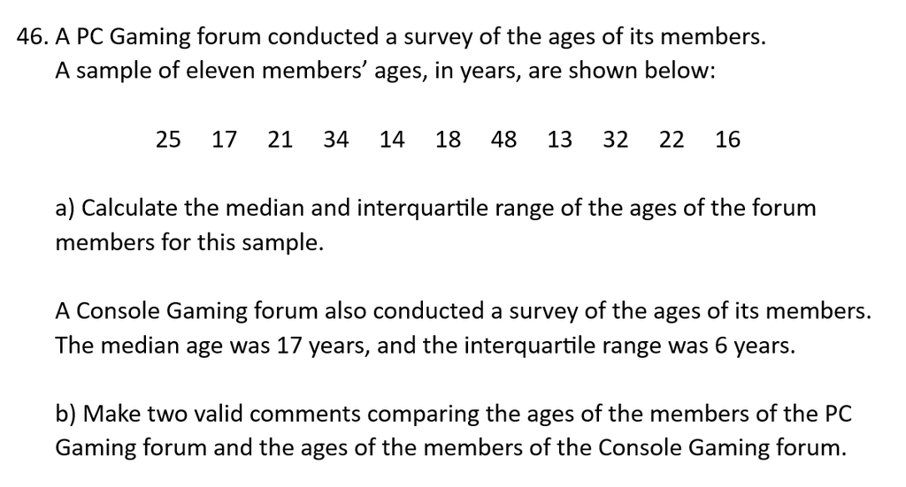

Start by putting the numbers *in order*...

1. Median = 21, interquartile range = 16.
2. Compare your comments to those in the solution, or ask your teacher to check them.

[figure not shown]

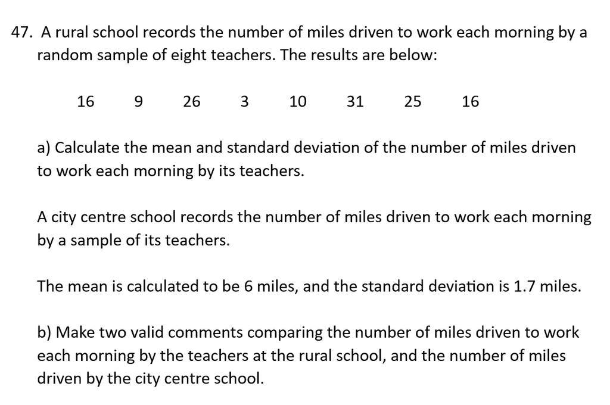

There are *two formulae* on the formula sheet for standard deviation. Check your notes to see *which one* your teacher taught you how to use.

1. Mean = 17, standard deviation = 9.7.
2. Compare your comments to those in the solution, or ask your teacher to check them.

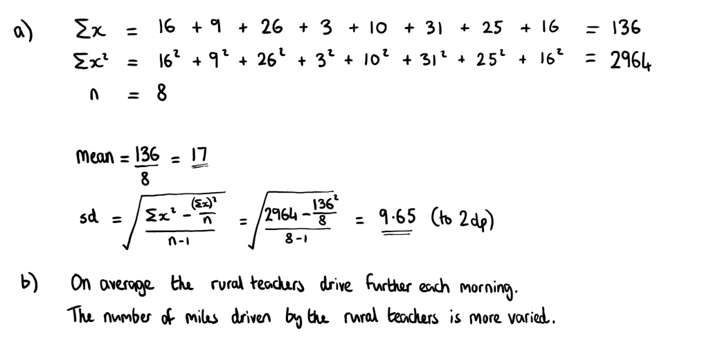

## Quadratics

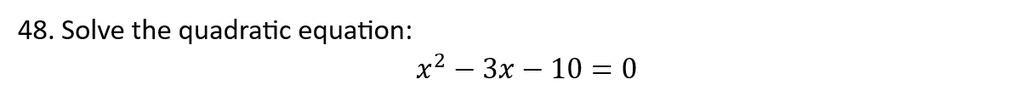

To solve a quadratic equation, you will usually want to *factorise* first.

$x=-2,x=5$

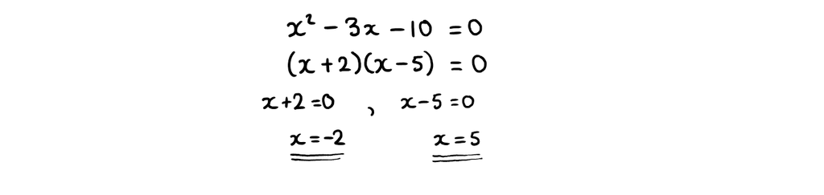

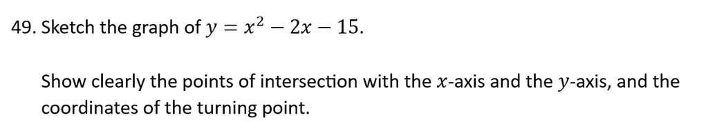

"$y$-*intercepts when* $x=0$..." "*Roots when* $y=0$..." "*The* $x$-*coordinate of the turning point lies in the middle of the roots...* "

$y$-intercept at $(0,-15)$ Roots at $(5,0)$ and $(-3,0)$ Minimum turning point at $(1,-16)$

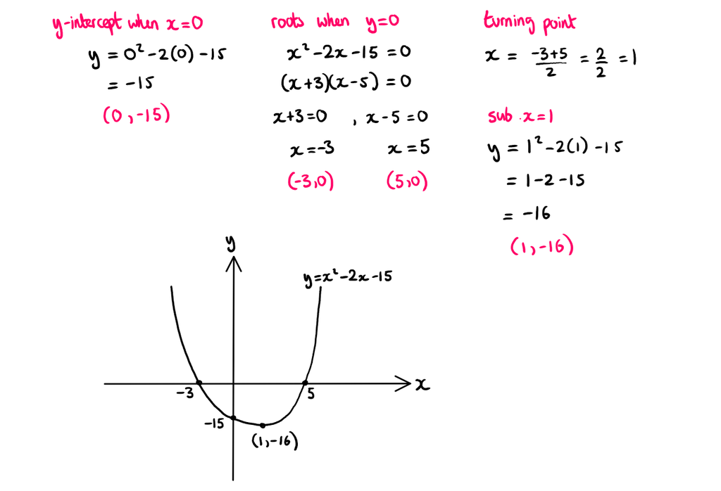

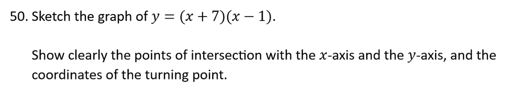

Make sure you label all your coordinates *on the sketch*. If any numbers don't make sense, check to see if you have done something wrong.

$y$-intercept at $(0,-7)$ Roots at $(1,0)$ and $(-7,0)$ Minimum turning point at $(-3,-16)$

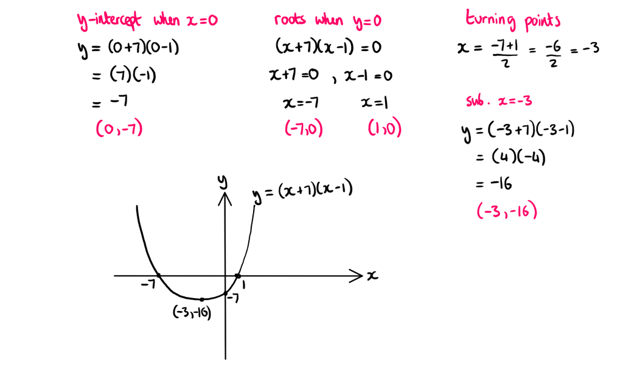

## Arcs and Sectors

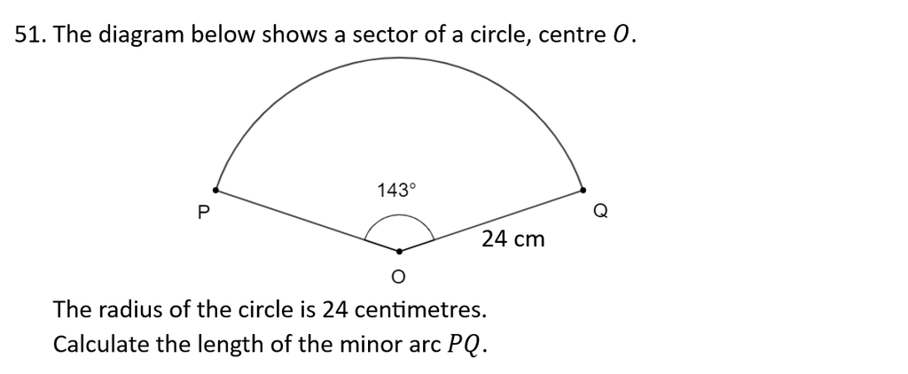

An arc is a *fraction of a circumference*.

$59.9\text{ cm}$

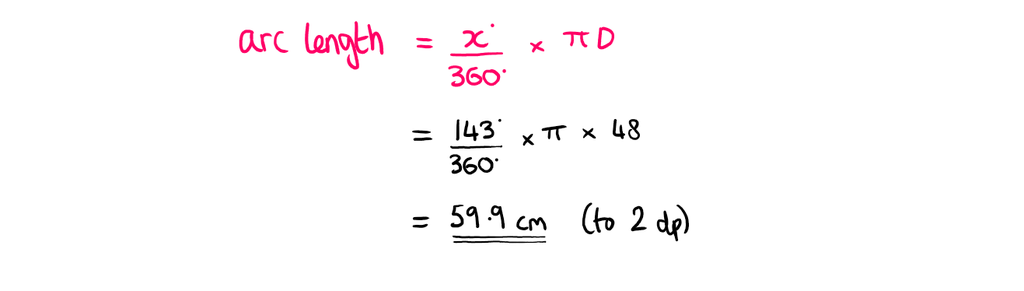

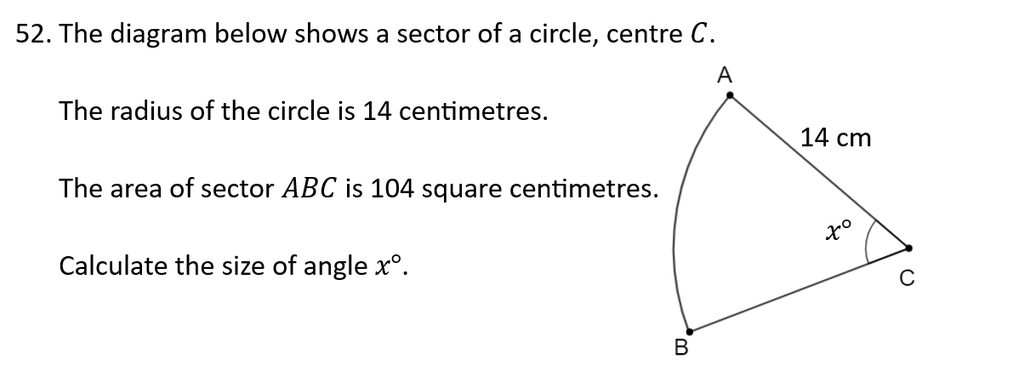

This is another example of substituting into a formula then *rearranging*.

$60.8^{\circ}$

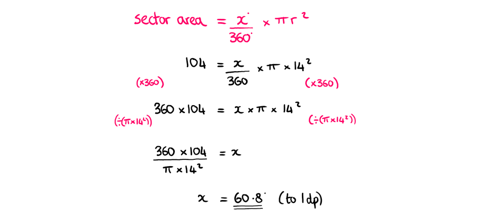

## Changing the Subject

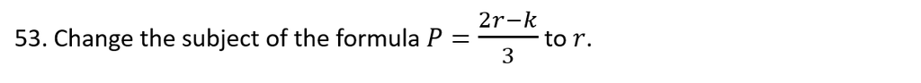

Deal with $r$ being within a *fraction* first.

$r=\dfrac{3P+k}{2}$

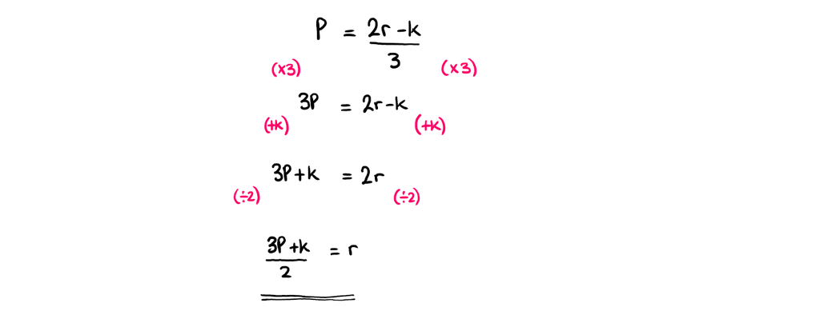

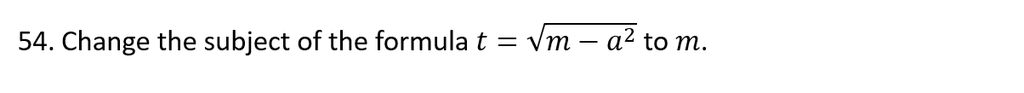

Deal with $m$ being within a *square root* first.

$m=t^2+a^2$

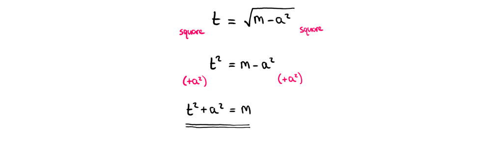

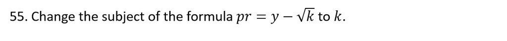

As with the previous example, the letter is within a square root. But that doesn't mean you should deal with the square root *right away*.

$k=(y-pr)^2$

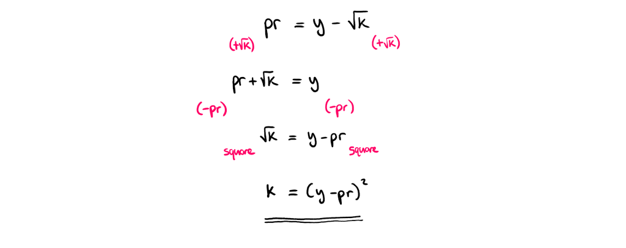